# Homework 3 PSTAT 131/231

### Question 3

Using the **training** data set, create a correlation matrix of all continuous variables. Create a visualization of the matrix, and describe any patterns you see. Are any predictors correlated with each other? Which ones, and in which direction?

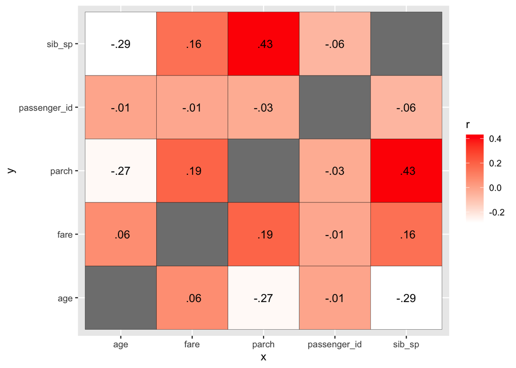

```r
correlation_titanic <- titanic_train %>%
  select(is.numeric) %>%
  correlate() %>%
  stretch() %>%
  ggplot(aes(x, y, fill = r)) + geom_tile() +
  geom_tile(color = "black") +
  scale_fill_gradient(low = "white", high = "red") +
  geom_text(aes(label = as.character(fashion(r))))
correlation_titanic
```

There doesn’t look like there is much correlation between them. Only significant one that is positicely corelated is the sib_sp and parch which has to do with sibling/spouse and parent/children.

### Question 4

Using the **training** data, create a recipe predicting the outcome variable `survived`. Include the following predictors: ticket class, sex, age, number of siblings or spouses aboard, number of parents or children aboard, and passenger fare.

Recall that there were missing values for `age`. To deal with this, add an imputation step using `step_impute_linear()`. Next, use `step_dummy()` to **dummy** encode categorical predictors. Finally, include interactions between:

- Sex and passenger fare, and
- Age and passenger fare.

```r
titanic_recipe <-
  recipe(survived ~ pclass + sex + age +
           sib_sp + parch + fare, data = titanic_train) %>%
  step_impute_linear(age, impute_with = imp_vars(all_predictors())) %>%
  step_dummy(all_nominal_predictors()) %>%
  step_interact(terms = ~sex_male:fare) %>%
  step_interact(terms = ~age:fare)
titanic_recipe
```

```
## Recipe
##
## Inputs:
##
##       role #variables
##    outcome          1
##  predictor          6
##
## Operations:
##
## Linear regression imputation for age
## Dummy variables from all_nominal_predictors()
## Interactions with sex_male:fare
## Interactions with age:fare
```

You’ll need to investigate the `tidymodels` documentation to find the appropriate step functions to use.

### Question 5

Specify a **logistic regression** model for classification using the `"glm"` engine. Then create a workflow. Add your model and the appropriate recipe. Finally, use `fit()` to apply your workflow to the **training** data.

*Hint: Make sure to store the results of `fit()`. You’ll need them later on.*

```r
titanic_logistic <- logistic_reg() %>%
  set_engine("glm") %>%
  set_mode("classification")

titanic_logistic_wkflow <- workflow() %>%
  add_model(titanic_logistic) %>%
  add_recipe(titanic_recipe)

titanic_logistic_fit <- fit(titanic_logistic_wkflow, titanic_train)
```

### Question 6

**Repeat Question 5**, but this time specify a linear discriminant analysis model for classification using the `"MASS"` engine.

```r
titanic_lda <- discrim_linear() %>%
  set_mode("classification") %>%
  set_engine("MASS")

titanic_lda_wkflow <- workflow() %>%
  add_model(titanic_lda) %>%
  add_recipe(titanic_recipe)

titanic_lda_fit <- fit(titanic_lda_wkflow, titanic_train)
```

### Question 7

**Repeat Question 5**, but this time specify a quadratic discriminant analysis model for classification using the `"MASS"` engine.

```r
titanic_qda <- discrim_quad() %>%
  set_mode("classification") %>%
  set_engine("MASS")

titanic_qda_wkflow <- workflow() %>%
  add_model(titanic_lda) %>%
  add_recipe(titanic_recipe)

titanic_qda_fit <- fit(titanic_qda_wkflow, titanic_train)
```

### Question 8

**Repeat Question 5**, but this time specify a naive Bayes model for classification using the `"klaR"` engine. Set the `usekernel` argument to `FALSE`.

```r
titanic_nb <- naive_Bayes() %>%
  set_mode("classification") %>%
  set_engine("klaR") %>%
  set_args(usekernel = FALSE)

titanic_nb_wkflow <- workflow() %>%
  add_model(titanic_nb) %>%
  add_recipe(titanic_recipe)

titanic_nb_fit <- fit(titanic_nb_wkflow, titanic_train)
```

### Question 9

Now you’ve fit four different models to your training data.

Use `predict()` and `bind_cols()` to generate predictions using each of these 4 models and your **training** data. Then use the *accuracy* metric to assess the performance of each of the four models.

```r
titanic_log_reg_pred <- predict(titanic_logistic_fit,
                           new_data = titanic_train)
titanic_lda_pred <- predict(titanic_lda_fit,
                           new_data = titanic_train)
titanic_qda_pred <- predict(titanic_qda_fit,
                           new_data = titanic_train)
titanic_nb_pred <- predict(titanic_nb_fit,
                           new_data = titanic_train)
titanic_train_pred <- bind_cols(titanic_log_reg_pred,
                                titanic_lda_pred,
                                titanic_qda_pred,
                                titanic_nb_pred,
                                titanic_train$survived)

titanic_train_pred
```

```
## # A tibble: 623 × 5
##    .pred_class...1 .pred_class...2 .pred_class...3 .pred_class...4 ...5
##    <fct>           <fct>           <fct>           <fct>           <fct>
##  1 No              No              No              No              No
##  2 No              No              No              No              No
##  3 No              No              No              No              No
##  4 No              Yes             Yes             No              No
##  5 No              Yes             Yes             No              No
##  6 No              No              No              No              No
##  7 No              No              No              Yes             No
##  8 No              No              No              No              No
##  9 No              No              No              No              No
## 10 No              No              No              No              No
## # … with 613 more rows
```

```r
titanic_log_reg_acc <- augment(titanic_logistic_fit, new_data = titanic_train) %>%
  accuracy(truth = survived, estimate = .pred_class)
titanic_lda_acc <- augment(titanic_lda_fit, new_data = titanic_train) %>%
  accuracy(truth = survived, estimate = .pred_class)
titanic_qda_acc <- augment(titanic_qda_fit, new_data = titanic_train) %>%
  accuracy(truth = survived, estimate = .pred_class)
titanic_nb_acc <- augment(titanic_nb_fit, new_data = titanic_train) %>%
  accuracy(truth = survived, estimate = .pred_class)

titanic_accuracies <- c(titanic_log_reg_acc$.estimate,
                        titanic_lda_acc$.estimate,
                        titanic_qda_acc$.estimate,
                        titanic_nb_acc$.estimate)
titanic_accuracies
```

```
## [1] 0.8170144 0.8057785 0.8057785 0.7720706
```

Which model achieved the highest accuracy on the training data?

### Question 10

Fit the model with the highest training accuracy to the **testing** data. Report the accuracy of the model on the **testing** data.

Again using the **testing** data, create a confusion matrix and visualize it. Plot an ROC curve and calculate the area under it (AUC).

How did the model perform? Compare its training and testing accuracies. If the values differ, why do you think this is so?

```r
titanic_test_pred <- predict(titanic_logistic_fit,
                             new_data = titanic_test,
                             type = "prob") %>%
  bind_cols(titanic_test %>% select(survived))
titanic_matrix <- augment(titanic_logistic_fit, new_data = titanic_test) %>%
  conf_mat(truth = survived, estimate = .pred_class)
titanic_test_acc <- augment(titanic_logistic_fit, new_data = titanic_test) %>%
  accuracy(truth = survived, estimate = .pred_class)
titanic_roc_plot <- augment(titanic_logistic_fit, new_data = titanic_test) %>%
  roc_curve(survived, .pred_Yes) %>%
  autoplot()

titanic_test_pred
```

```
## # A tibble: 268 × 3
##    .pred_Yes .pred_No survived
##        <dbl>    <dbl> <fct>
##  1    0.0844   0.916  No
##  2    0.0833   0.917  No
##  3    0.0575   0.942  No
##  4    0.902    0.0980 Yes
##  5    0.720    0.280  Yes
##  6    0.0222   0.978  No
##  7    0.724    0.276  No
##  8    0.0310   0.969  No
##  9    0.255    0.745  Yes
## 10    0.579    0.421  Yes
## # … with 258 more rows
```

```r
titanic_test_pred
```

```
## # A tibble: 268 × 3
##    .pred_Yes .pred_No survived
##        <dbl>    <dbl> <fct>
##  1    0.0844   0.916  No
##  2    0.0833   0.917  No
##  3    0.0575   0.942  No
##  4    0.902    0.0980 Yes
##  5    0.720    0.280  Yes
##  6    0.0222   0.978  No
##  7    0.724    0.276  No
##  8    0.0310   0.969  No
##  9    0.255    0.745  Yes
## 10    0.579    0.421  Yes
## # … with 258 more rows
```

```r
titanic_matrix
```

```
##           Truth
## Prediction Yes  No
##        Yes  71  17
##        No   32 148
```

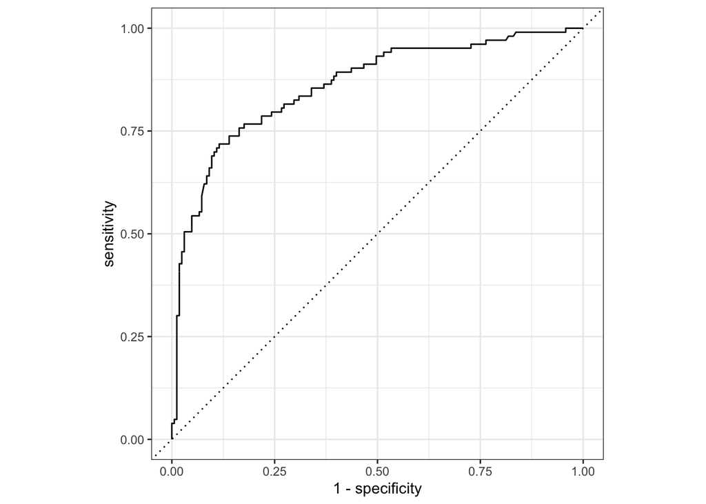

```r
titanic_roc_plot
```

```r
titanic_roc_auc <- titanic_test_pred %>%
  roc_auc(survived, .pred_Yes)
```

```r
titanic_roc_auc$.estimate
```

```
## [1] 0.8601059
```

```r
titanic_log_reg_acc$.estimate
```

```
## [1] 0.8170144
```

```r
titanic_test_acc$.estimate
```

```
## [1] 0.8171642
```